# Colorize QML Type

Sets the color in the HSL color space. More...

| Import Statement: | `import Qt5Compat.GraphicalEffects` |
| --- | --- |
| Since: | QtGraphicalEffects 1.0 |
| Inherits: | Item |

- [List of all members, including inherited members](https://doc.qt.io/qt-6.9/qml-qt5compat-graphicaleffects-colorize-members.html)

## Properties

- **cached** : bool
- **hue** : real
- **lightness** : real
- **saturation** : real
- **source** : variant

## Detailed Description

The effect is similar to what happens when a colorized glass is put on top of a grayscale image. Colorize uses the hue, saturation, and lightness (HSL) color space. You can specify a desired value for each property. You can shift all HSL values with the HueSaturation effect.

Alternatively, you can use the ColorOverlay effect to colorize the source item in the RGBA color space.

Effect applied

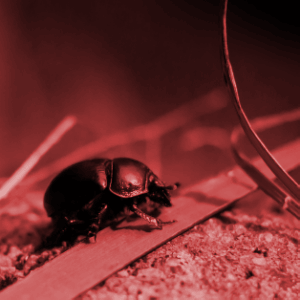

## Example

The following example shows how to apply the effect.

```
import QtQuick
import Qt5Compat.GraphicalEffects

Item {
    width: 300
    height: 300

    Image {
        id: bug
        source: "images/bug.jpg"
        sourceSize: Qt.size(parent.width, parent.height)
        smooth: true
        visible: false
    }

    Colorize {
        anchors.fill: bug
        source: bug
        hue: 0.0
        saturation: 0.5
        lightness: -0.2
    }
}
```

## Property Documentation

### cached : bool

This property allows the effect output pixels to be cached in order to improve the rendering performance.

Every time the source or effect properties are changed, the pixels in the cache must be updated. Memory consumption is increased, because an extra buffer of memory is required for storing the effect output.

It is recommended to disable the cache when the source or the effect properties are animated.

By default, the property is set to `false`.

### hue : real

This property defines the hue value which is used to colorize the source.

Allowed hue values

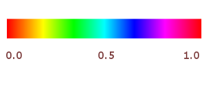

Output examples with different hue values

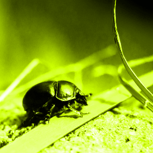

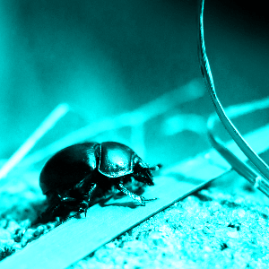

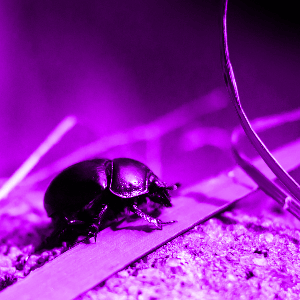

**hue: 0.2**

**hue: 0.5**

**hue: 0.8**

saturation: 1

saturation: 1

saturation: 1

lightness: 0

lightness: 0

lightness: 0

### lightness : real

This property defines how much the source lightness value is increased or decreased.

Unlike hue and saturation properties, lightness does not set the used value, but it shifts the existing source pixel lightness value.

The value ranges from -1.0 (decreased) to 1.0 (increased). By default, the property is set to `0.0` (no change).

Output examples with different lightness values

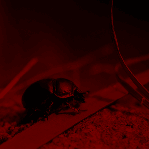

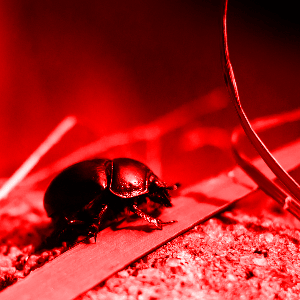

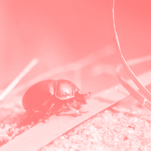

**lightness: -0.75**

**lightness: 0**

**lightness: 0.75**

hue: 0

hue: 0

hue: 0

saturation: 1

saturation: 1

saturation: 1

### saturation : real

This property defines the saturation value which is used to colorize the source.

The value ranges from 0.0 (desaturated) to 1.0 (saturated). By default, the property is set to `1.0` (saturated).

Output examples with different saturation values

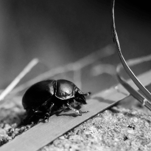

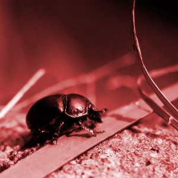

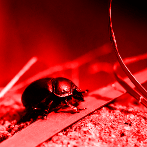

**saturation: 0**

**saturation: 0.5**

**saturation: 1**

hue: 0

hue: 0

hue: 0

lightness: 0

lightness: 0

lightness: 0

### source : variant

This property defines the source item that provides the source pixels for the effect.

**Note:** It is not supported to let the effect include itself, for instance by setting source to the effect's parent.

© The Qt Company Ltd  
Licensed under the GNU Free Documentation License, Version 1.3.  
https://doc.qt.io/qt-6.9/qml-qt5compat-graphicaleffects-colorize.html